# Maths and Statistics Foundations Project

Team N: Darren Tan (01436826), Joachim Kibsgaard-Petersen (01275660), Linn Bieske (01453725), Qi Zhang (01408680), Sarah Laouiti (01429506), Wenyu Guo (01380750)

# 1. Introduction

During many situations within a commercial context, however, no information about a person’s salary is provided or can be checked independently. Thus, a model predicting a customer’s salary would be crucial for businesses in order to estimate the customer’s wealth - in terms of their income level, allowing a business to make individual and personalised decisions for each customer. The aim of the project is therefore to create a model that can fulfill this objective.

In order to do so, we need to determine significant variables that influence salary. After consulting several literature sources, a set of significant variables was determined - including sex, industry sector, educational qualification and age. A descriptive exploration of the chosen parameters in the data set would serve as a guidance for identifying differences in salary.

The built predictive model can provide potential application in different industries and could allow for transferability across different countries with a socioeconomic structure that is similar to the United Kingdom. Another benefit of this model would be the possibility of predicting a person’s salary living in a country for which data is less available for a model to be substantially developed.

# 2. Theory

Differences in salary is commonplace in today’s reality. Reasons behind why there might be a difference in salary are linked to the existence of an income gap in society (Blinder, 1973). Abovementioned are variables such as sex, age, ethnicity, industrial sector and educational qualifications that are believed to have an impact on salary.

A widely discussed form of this discrepancy in income is gender. The European Commission defines gender pay gap as “the difference between men’s and women’s pay, based on the average difference in gross hourly earnings of all employees” (European Commission, 2017). In recent years especially, addressing the gender-related pay gap has been a policy matter of many countries namely those belonging to the European Union (European Union, 2014). According to Kickbusch and Riedmüller (1984) and Gerhard et al. (1988), the occurrence of this form of difference in salary is apparent as a result of gender discrimination in contemporary society, which has arisen primarily from established hierarchy within a family.

It is worth investigating whether this apparent income gap is a result of actual gender discrimination or whether this phenomenon arises as a result of other variables’ influences. In that aspect, this investigation will determine other possible causes of the income gap and whether working in different industry sectors or having different educational qualifications can affect salary when included in a linear regression model with salary as the independent variable.

A person’s age can be related to salary through other implications. It is most logical that in general, a person who is older would have more work experience than a young teenager and would therefore have a larger salary. This can also be said of educational qualification where an older person would generally have attained a higher level of education compared to someone who is younger. It is also true that an industry where a person works in would affect the salary of the person (Bovill, 2015). Logically, someone who is employed in a job where less qualification is necessary would earn less than another individual employed in a professional field. In terms of marriage, there is some sort of implication by Landau and Arthur (1992) that married people seem to earn more than people who have never been married.

According to Brynin and Güveli (2012), ethnic pay gaps are resultant from either the the majority of the ethnic minority group going into more less well-paid careers or that they are merely generally paid less for doing the same kind of work. Fryer (2014) bases the reason why there is a difference between the incomes of people with different ethnic backgrounds on academic grounds, providing further motivation as to why including educational qualification as a variable in the linear regression model is a viable choice.

Consequently, in order to achieve the report aim, data from the Office of National Statistics Quarterly Labour Force Survey (QLFS) for the period of January to March 2017 will be utilised. Following the investigation of the variables and after modelling linear regressions, inferences will be made that can hopefully aid in the creation of policies associated with salary.

Therefore, the null hypothesis is that all the predictors will not have a significant effect on salary. The alternative hypothesis is that the predictors do have a significant effect on salary.

# 3. Methods

The research into the dataset involves the use of various statistical tools in R. The “ggplot” and “knitr” libraries have been imported to help visualise the data. The “dplyr” library has been used to ease the process of data manipulation and the library “lmtest” is implemented to further statistical research.

## 3.1 Data Description

The dataset initially consisted of 88,528 observations of 739 variables. This covers 88,528 independent individuals from the UK. The QLFS aims to “inform social, economic and employment policy” (ONS, 2017). As such, the questionnaire covers questions on individual demographics, household characteristics and job information.

In order to further examine the underlying problem of an income gap as well as the relationship between salary and gender and explore the possibility of gender discrimination in the UK, certain variables have been selected such that the final dataset contains 543 observations of 11 variables. These are outlined below.

| Variable | Description | Further information |
| --- | --- | --- |
| `Salary` | Salary of respondent (249.5 - 48000.0) | N.b. adjusted for inflation |
| `Age` | Age of respondent (0-99) |  |
| `Sex` | Gender of respondent | **Male** |
| `Occupation` | Major occupation group of respondent | **Managers, Directors and Senior Officials** |
| `Industry` | Industry sector in main job | **Distribution, hotels, restaurants** |
| `Education` | Highest qualification level | **Degree** |
| `NumEmployee` | Number of employees at workplace | **Under 50** |
| `Religion` | Religion GB level | **No** |
| `MaritalStatus` | Marital status | **Single** |
| `Ethnicity` | Ethnicity of respondent in GB | **White** |
| `Region of workplace` | Region of place of work | **North East** |

**base category**

For ease of analysis, the smaller dataset is manipulated. Salary was converted from intervals to continuous data to allow for a linear regression with salary as the dependent variable and all other variables are condensed to a set number of dummy variables. Furthermore, all variables (except salary) are converted to factors.

```r
summary(facQlfs)
```

```
##       Age           Sex                                   Industry
##  Min.   :16.0   Male  :262   Distribution, hotels, restaurants:111
##  1st Qu.:30.0   Female:281   Banking, Finance                 : 82
##  Median :43.0                Public admin, education, health  :203
##  Mean   :42.1                Other                            :147
##  3rd Qu.:53.0
##  Max.   :77.0
##
##             Education      NumEmployee
##  Degree          :164   Under 50 :268
##  Higher Education: 51   Under 500:183
##  A Level         :115   Over 500 : 92
##  GCSE A*-C       :127
##  Other           : 52
##  No              : 34
##
##                                  Occupation      Salary
##  Professional                         :105   Min.   :  249.5
##  Caring, Leisure, Other Service       : 75   1st Qu.:10499.5
##  Associate Professional, Technical    : 66   Median :18499.5
##  Administrative, Secretarial          : 61   Mean   :20860.0
##  Managers, Directors, Senior Officials: 55   3rd Qu.:30499.5
##  Sales, Customer Service              : 53   Max.   :48000.0
##  (Other)                              :128
##     Marital    Religion  Ethnicity                      workRegion
##  Single :213   No :208   White:486   South East              :121
##  Married:268   Yes:335   Asian: 21   Yorkshire and the Humber: 96
##  Other  : 62             Black: 15   London                  : 91
##                          Other: 21   South West              : 67
##                                      North East              : 54
##                                      West Midlands           : 47
##                                      (Other)                 : 67
```

## 3.2 Strength and limitations

The data set is from the UK Office for National Statistics, which is a reliable and unbiased provider of information. A notable strength of the data set is its coverage of a broad range of questions and topics addressing social, economic and employment policy. In the data set, employment and economic activities are surveyed. Related topics such as occupation, training, hours of work and personal characteristics of household members aged 16 years and over are also covered.

The application of international definitions of unemployment and economic inactivity led to a data set that can be compared to other standardised international surveys. The processing of this data set was carried out according to the highest UK Data Archive standard ’A*’. Hence, the quality of this data and documentation will not be compromised.

Despite these strengths, limitations and challenges have to be considered. During the data analysis, certain observations were identified to not be meaningful. Some questions within the survey were unanswered or the option “Not Applicable” was chosen. Such observations are inconclusive and are not beneficial for a high-performing regression model. Consequently, these observations were dropped.

As numerous observations were excluded from the regression model, the size of the data set was decreased. The minimisation in the data set resulted in the limitation of the precision of the regression model. Additionally, due to the exclusion of observations, some of the predictors became less significant as the observations are no longer evenly spread such as in the case of the ethnicity variable. Moreover, most of the variable are of a categorical nature, enforcing the use of dummy variables. This poses additional challenges during the development of the regression model.

# 4. Analysis

## 4.1 Univariate descriptive of variables

#### Age

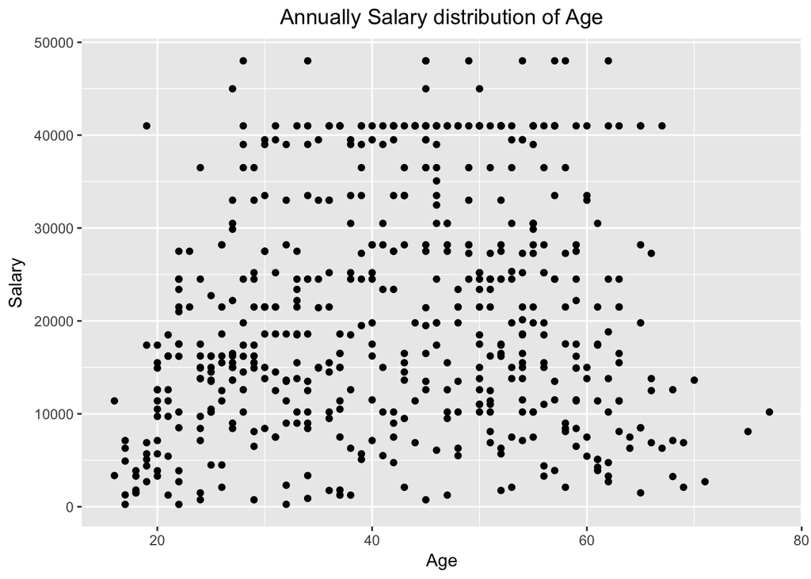

Based on the above scatter plot, there is not much information to be drawn from it. There may be a relatively small positive linear relationship between age and salary. Hence, a correlation test could be introduced in the analysis.

#### Sex

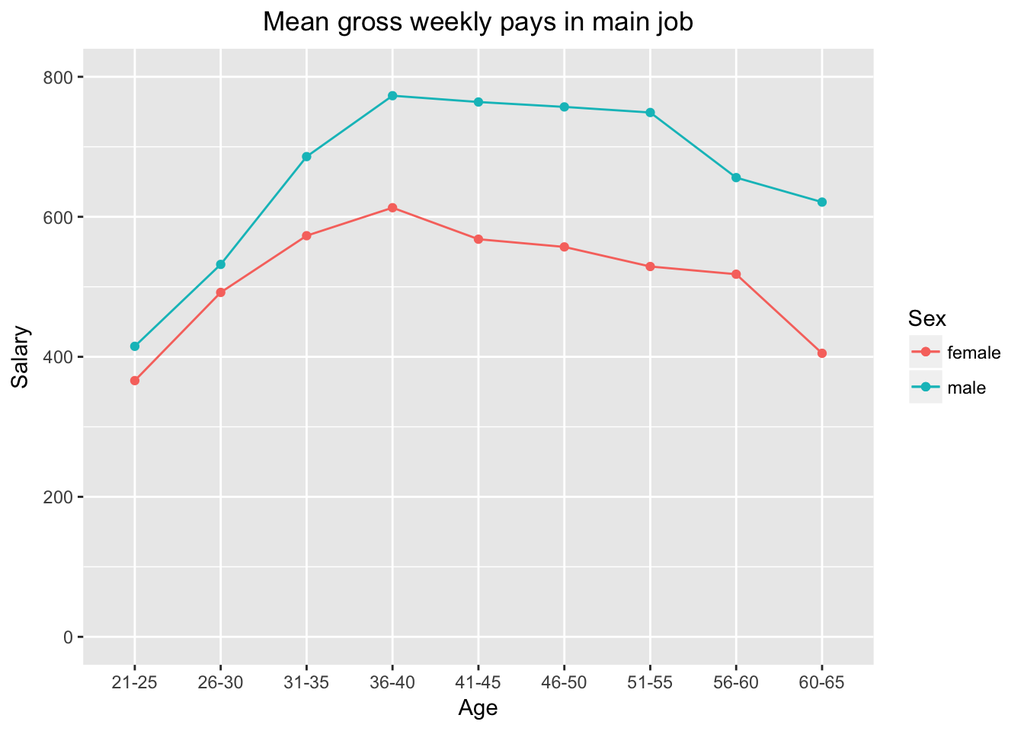

*Adapted from the Office of National Statistics 2017*

This initial observation, along with the above plot, seems to corroborate that males on average get higher salaries than females.

| Sex | Mean | Standard Deviation |
| --- | --- | --- |
| Male | 25812.52 | 12614.71 |
| Female | 16242.32 | 10833.12 |

#### Industry

The three main industries of employments are compared with one another: 21% of the sampled population work in “Distribution, hotels and restaurants”, 15% work in “Banking and Finance” whilst 38% work in “Public administration, education, health”. All remaining industry jobs are summarised and aggregated in the category “Other”.

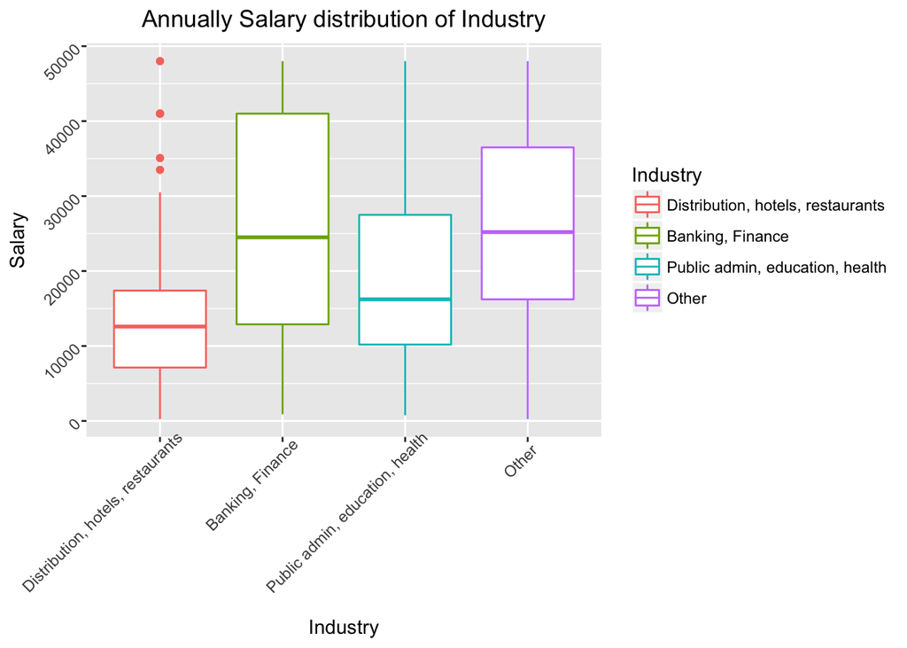

The above reveals clear differences between the most common three industry sectors regarding salary. The highest median salary can be found in the banking and finance industry. The median salary of the public administration, education and health industry sector is lower than the median of the finance and banking industry sector. However it is at the same time higher than the median salary of the distribution, hotel and restaurant sector. In comparison to these three main industry sectors, the median salary of all other industries is at the level of the banking and finance industry.

| Industry | Mean | Standard Deviation |
| --- | --- | --- |
| Distribution, hotels, restaurants | 13894.55 | 9311.661 |
| Banking, Finance | 25477.55 | 14122.353 |
| Public admin, education, health | 18955.17 | 11926.377 |
| Other | 26174.29 | 11810.261 |

#### Occupations

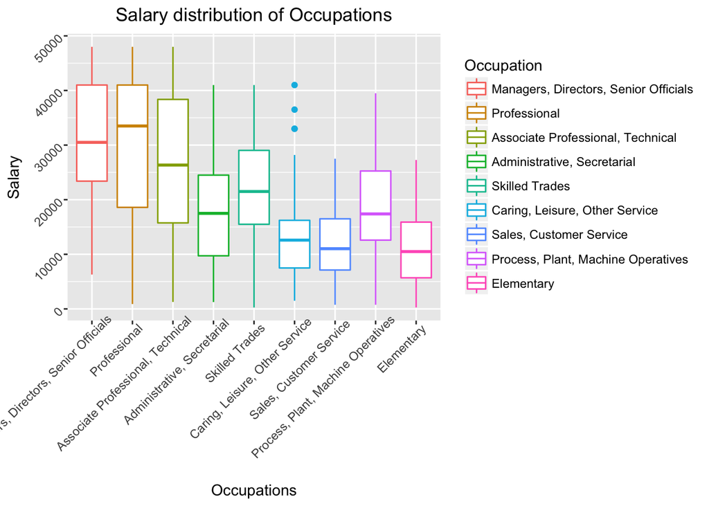

There is a visible difference in Skilled Trades to Caring, Leisure and Other Services. This suggests that people who are highly trained have higher salaries than less skilled individuals. Managers, Directors, Senior Officials and professional groups tend to earn the highest salary amongst the 9 groups. In the high-earning sectors, the Skilled Trades category earns more than the Administrative and Secretarial group. On the other hand, salaries for groups “Sales and Customer Service” and “Elementary” are not significantly different from each other. Furthermore, both of them are in the lower earning sector.

The median full-time gross weekly earnings for 2014 ([Annual Survey of Hours and Earnings, 2015](https://www.ons.gov.uk/employmentandlabourmarket/peopleinwork/earningsandworkinghours/bulletins/annualsurveyofhoursandearnings/2015provisionalresults#earnings-by-occupation)) demonstrated that different occupation groups would have different medians. As the skill level increases, the median earning follows. This aligns with the results observed so far.

Salary Mean and Standard Deviation by Occupation

| Occupation | Mean | Standard Deviation |
| --- | --- | --- |
| Managers, Directors, Senior Officials | 30682 | 11546 |
| Professional | 29018 | 12956 |
| Associate Professional, Technical | 25735 | 12872 |
| Administrative, Secretarial | 17732 | 10511 |
| Skilled Trades | 22152 | 10931 |
| Caring, Leisure, Other Service | 13442 | 8217 |
| Sales, Customer Service | 11954 | 6063 |
| Process, Plant, Machine Operatives | 18488 | 8791 |
| Elementary | 11130 | 6786 |

#### Highest Education Level

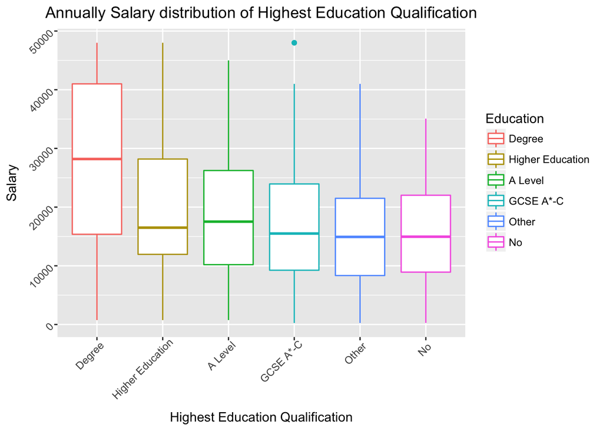

Earnings are related to the highest education qualification of employees. In general, people with higher education qualification levels earn higher incomes. A distinctive difference between median salaries can be observed from the above box plot, where employees holding degree qualifications earn on average 33% more than those with a higher education qualification. Apart from the median salary level, a higher IQR also suggests that people with a higher education level, especially the ones with degrees, earn a higher income in general than other groups.

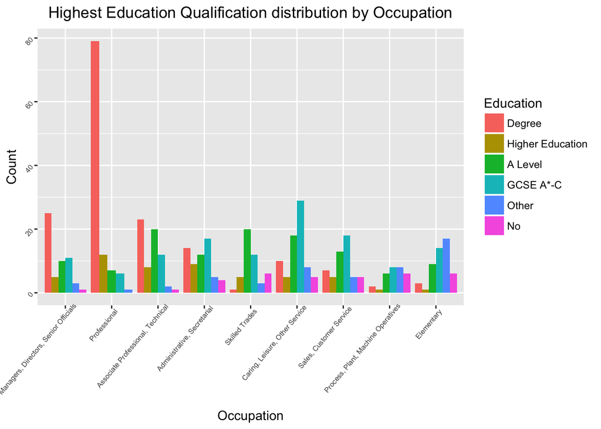

By further investigating the education qualification distribution among the different occupations, the above figure shows that people with degrees are mostly employed in professional jobs. They usually work in managerial or occupations which naturally would demand a greater skillset. Employees having lower level of qualifications are more likely to work in service and operative occupations like caring, customer service and machine operatives. However, employees holding lower qualifications are not barred from working in high-skilled occupations. Around 47% of people educated to a degree level work as professionals. This can be compared to a 14% distribution in the second largest occupation group, managers, directors and senior officials.

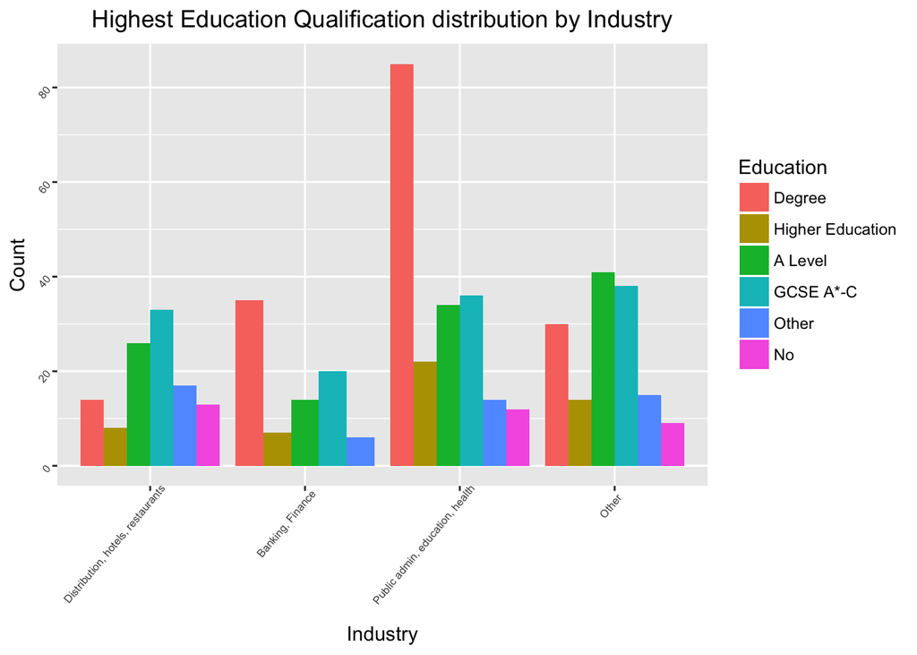

By looking at the bar chart of industry sector by education, the majority of people who have a degree go into public admission, education, and health fields instead of banking and finance. This is interesting as we would have expected from our previous analysis that those who work in banking and finance would earn more than the other fields. Moreover, this implies that an individual is restricted in what industry sector he or she can enter if not equipped with any educational qualification.

Salary Mean and Standard Deviation by Education

| Education | Mean | Standard Deviation |
| --- | --- | --- |
| Degree | 27478 | 13489 |
| Higher Education | 20437 | 12662 |
| A Level | 19052 | 11375 |
| GCSE A*-C | 17512 | 11227 |
| Other | 15926 | 9723 |
| No | 15738 | 8761 |

#### Employee Numbers in workplace

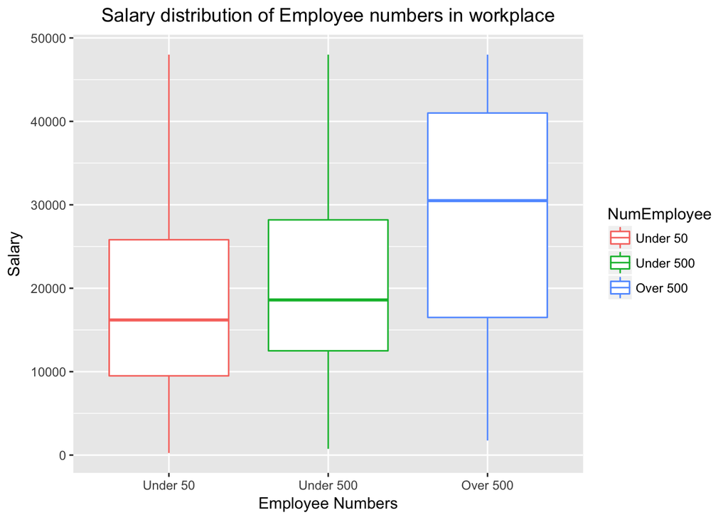

Salary Mean and Standard Deviation by # of Employees

| NumEmployee | Mean | Standard Deviation |
| --- | --- | --- |
| Under 50 | 18305 | 11951 |
| Under 500 | 20966 | 12002 |
| Over 500 | 28092 | 13217 |

#### Religion

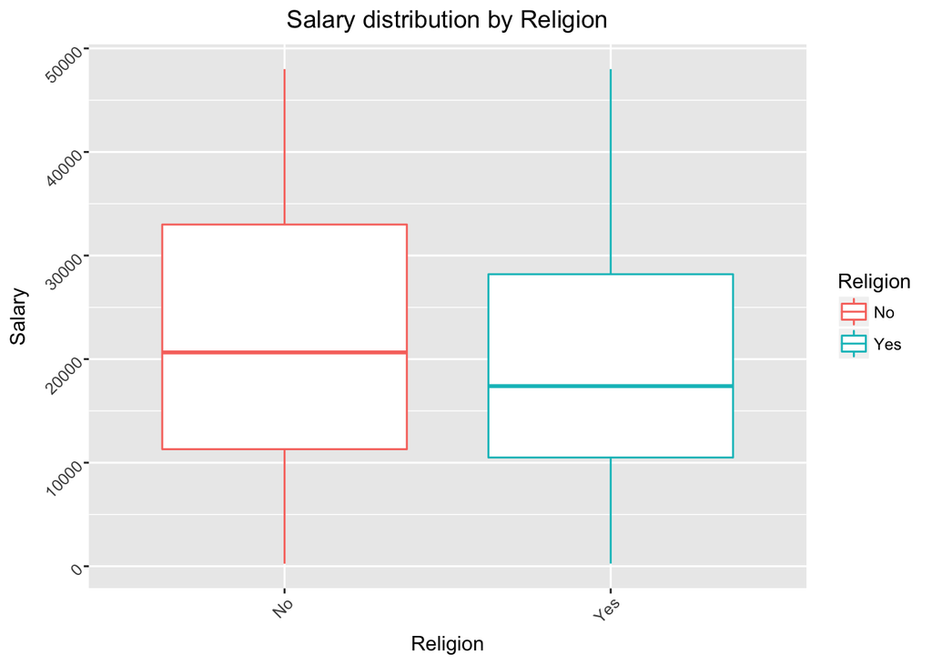

Salary Mean and Standard Deviation by Religion

| Religion | Mean | Standard Deviation |
| --- | --- | --- |
| No | 22127 | 13045 |
| Yes | 20073 | 12362 |

It seems like there is no big difference between individuals who have a religion and those who do not. The medians are not really different from each other. It may be possible that this variable does not affect salary.

#### Marital Status

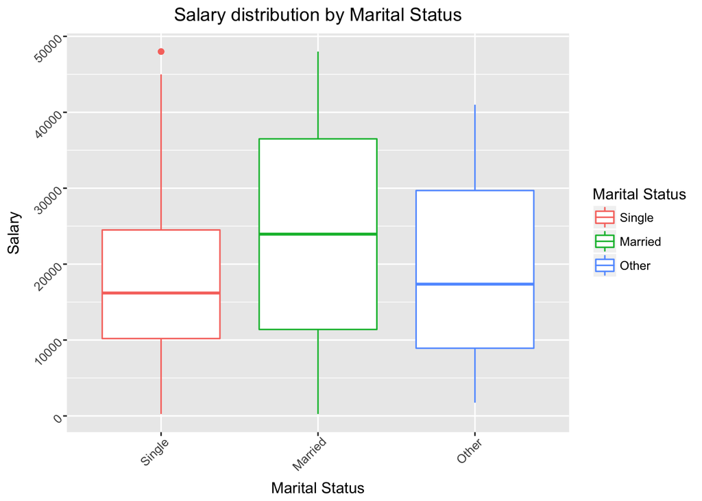

Married individuals have a slightly higher median than those who are single or other (i.e. widow or divorced). There is only a slight difference between single and other; only the range of percentile is different.

#### Ethnicity

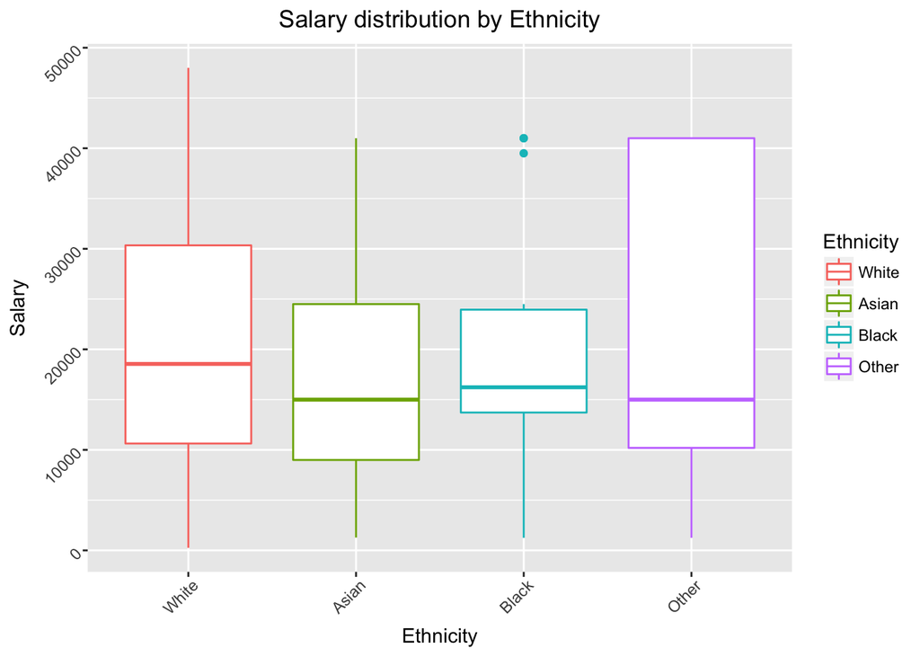

Salary Mean and Standard Deviation by Ethnicity

| Ethnicity | Mean | Standard Deviation |
| --- | --- | --- |
| White | 20902 | 12565 |
| Asian | 18442 | 11889 |
| Black | 20273 | 11980 |
| Other | 22716 | 16131 |

The median for the four groups are essentially the same. However, the quantile range is different. Focusing on black people, the majority of people have a lower income of around 15000 pounds per year.

#### Region of Workplace

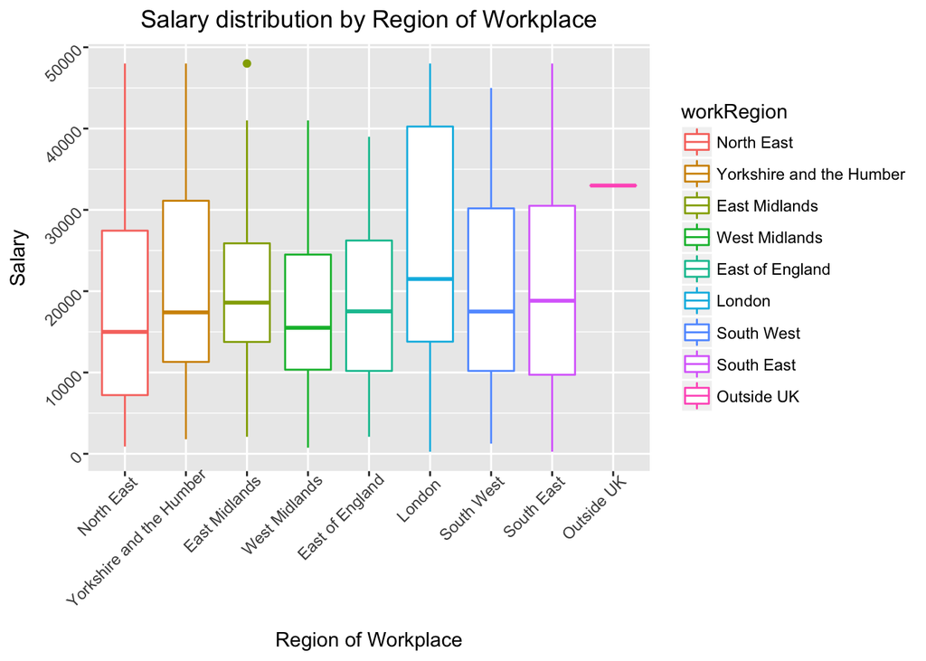

Salary Mean and Standard Deviation by Region of Workplace

[output not shown]

The various regions of workplace have similar median values as well as similar quantile ranges. It can be noted that only the ‘Outside UK’ category is different. However as there are only a few observations that fall into that category, they would be insignificant as not much information can be drawn from it.

## 4.2 Hypothesis tests

Prior to running a regression, further investigation into the variables is required. The correlation between age and salary will be checked. Furthermore, as there may be some association between occupation, industry sectors and education, a Chi-Square test for independence is used to check this.

### 4.2.1 Correlation Tests

$H_o$: There is no linear relationship between age and salary.

$H_a$: There is a linear relationship between age and salary.

```
##
##  Pearson's product-moment correlation
##
## data:  qlfs$Age and qlfs$Salary
## t = 3.5774, df = 541, p-value = 0.0003781
## alternative hypothesis: true correlation is not equal to 0
## 95 percent confidence interval:
##  0.06875346 0.23317929
## sample estimates:
##      cor
## 0.152018
```

### 4.2.2 Chi-Squared Tests for Independence

$H_o$: The two categorical variables are independent from each other.

$H_a$: The two categorical variables are not independent from each other.

```
##
##  Pearson's Chi-squared test
##
## data:  table(facQlfs$Industry, facQlfs$Education)
## X-squared = 57.811, df = 15, p-value = 5.975e-07
```

```
##
##  Pearson's Chi-squared test
##
## data:  table(facQlfs$Education, facQlfs$Occupation)
## X-squared = 252.74, df = 40, p-value < 2.2e-16
```

The p-values are far smaller than the significance level of 0.1% for both tests. This means $H_o$ can be rejected. It can thus be concluded that there is an association between education and industry as well as education and occupation.

## 4.3 Multiple Linear Regression with full dataset

```r
facQlfs.lm1 <- lm(Salary~ Age+Education+Sex+Industry+NumEmployee+Occupation+Marital+Religion+Ethnicity+workRegion,data=facQlfs )
```

|  | Salary |
| --- | --- |
| Age | 86.455** |
|  | (39.383) |
| EducationHigher Education | -4,188.572*** |
|  | (1,541.352) |
| EducationA Level | -4,615.660*** |
|  | (1,325.412) |
| EducationGCSE A* -C | -4,669.586*** |
|  | (1,299.537) |
| EducationOther | -4,545.559*** |
|  | (1,733.268) |
| EducationNo | -5,576.106*** |
|  | (1,977.722) |
| SexFemale | -6,652.217*** |
|  | (947.721) |
| IndustryBanking, Finance | 3,002.833* |
|  | (1,600.076) |
| IndustryPublic admin, education, health | -855.601 |
|  | (1,459.667) |
| IndustryOther | 5,234.178*** |
|  | (1,418.946) |
| NumEmployeeUnder 500 | 1,005.625 |
|  | (929.524) |
| NumEmployeeOver 500 | 5,743.320*** |
|  | (1,208.647) |
| OccupationProfessional | -820.658 |
|  | (1,654.562) |
| OccupationAssociate Professional, Technical | -2,843.649 |
|  | (1,750.209) |
| OccupationAdministrative, Secretarial | -8,356.893*** |
|  | (1,814.005) |
| OccupationSkilled Trades | -7,686.221*** |
|  | (1,965.888) |
| OccupationCaring, Leisure, Other Service | -8,874.791*** |
|  | (1,886.559) |
| OccupationSales, Customer Service | -11,522.990*** |
|  | (2,061.745) |
| OccupationProcess, Plant, Machine Operatives | -12,145.610*** |
|  | (2,227.026) |
| OccupationElementary | -13,817.230*** |
|  | (2,029.206) |
| MaritalMarried | 627.700 |
|  | (1,075.299) |
| MaritalOther | 539.859 |
|  | (1,581.925) |
| ReligionYes | -1,332.738 |
|  | (861.518) |
| EthnicityAsian | -2,600.278 |
|  | (2,147.610) |
| EthnicityBlack | -1,331.264 |
|  | (2,514.910) |
| EthnicityOther | 79.161 |
|  | (2,139.832) |
| workRegionYorkshire and the Humber | 1,826.539 |
|  | (1,608.859) |
| workRegionEast Midlands | 1,654.292 |
|  | (1,924.709) |
| workRegionWest Midlands | -3,478.604* |
|  | (1,872.488) |
| workRegionEast of England | 2,171.689 |
|  | (2,345.244) |
| workRegionLondon | 2,162.767 |
|  | (1,630.275) |
| workRegionSouth West | 1,239.961 |
|  | (1,710.443) |
| workRegionSouth East | 1,238.539 |
|  | (1,539.444) |
| workRegionOutside UK | 10,824.310 |
|  | (9,546.072) |
| Constant | 27,001.530*** |
|  | (2,646.193) |
| *N* | 543 |
| R<sup>2</sup> | 0.508 |
| Adjusted R<sup>2</sup> | 0.475 |
| Residual Std. Error | 9,171.298 (df = 508) |
| F Statistic | 15.414*** (df = 34; 508) |
| *Notes:* | ***Significant at the 1 percent level. |
|  | **Significant at the 5 percent level. |
|  | *Significant at the 10 percent level. |

Based on the statistical summary, four variables (Religion, Marital Status, Ethnicity and Region of Workplace appear to not be significant at a 5% level of significance. In other words, regardless of which category an individual falls into within these four variables, it will not have a significant effect on the salary they are earning based on the model.

This result supports the lack of difference between the observed categories in the exploratory data analysis of these variables. Furthermore, dropping these variables contributes to achieving a parsimonious model.

Based on the Chi-Square independence test, as the variables are not independent from each other, there were considerations to drop one of the variables to reduce the complexity of the model. However, dropping any of the variables would reduce the model precision based on the adjusted R-square measure. Hence, both factors remain in the model whilst this relation is acknowledged.

## 4.4 Multiple Linear Regression with non-significant variables dropped

```r
facQlfs.lm2 <- lm(Salary ~ Age+ Education + Sex + Industry  + NumEmployee + Occupation,  data=facQlfs)
```

|  | Salary |  |
| --- | --- | --- |
|  | (1) | (2) |
| Age | 86.455** | 90.562*** |
|  | (39.383) | (31.907) |
| EducationHigher Education | -4,188.572*** | -4,226.837*** |
|  | (1,541.352) | (1,545.800) |
| EducationA Level | -4,615.660*** | -4,559.482*** |
|  | (1,325.412) | (1,306.543) |
| EducationGCSE A* -C | -4,669.586*** | -4,290.597*** |
|  | (1,299.537) | (1,279.548) |
| EducationOther | -4,545.559*** | -4,006.459** |
|  | (1,733.268) | (1,704.887) |
| EducationNo | -5,576.106*** | -5,087.257** |
|  | (1,977.722) | (1,970.964) |
| SexFemale | -6,652.217*** | -7,050.775*** |
|  | (947.721) | (926.129) |
| IndustryBanking, Finance | 3,002.833* | 3,391.934** |
|  | (1,600.076) | (1,584.344) |
| IndustryPublic admin, education, health | -855.601 | -857.047 |
|  | (1,459.667) | (1,461.344) |
| IndustryOther | 5,234.178*** | 4,875.223*** |
|  | (1,418.946) | (1,410.295) |
| NumEmployeeUnder 500 | 1,005.625 | 1,023.623 |
|  | (929.524) | (919.567) |
| NumEmployeeOver 500 | 5,743.320*** | 5,991.247*** |
|  | (1,208.647) | (1,179.729) |
| OccupationProfessional | -820.658 | -606.512 |
|  | (1,654.562) | (1,649.902) |
| OccupationAssociate Professional, Technical | -2,843.649 | -2,303.705 |
|  | (1,750.209) | (1,733.067) |
| OccupationAdministrative, Secretarial | -8,356.893*** | -8,169.104*** |
|  | (1,814.005) | (1,802.030) |
| OccupationSkilled Trades | -7,686.221*** | -7,592.074*** |
|  | (1,965.888) | (1,957.690) |
| OccupationCaring, Leisure, Other Service | -8,874.791*** | -8,762.079*** |
|  | (1,886.559) | (1,851.677) |
| OccupationSales, Customer Service | -11,522.990*** | -11,136.060*** |
|  | (2,061.745) | (2,041.705) |
| OccupationProcess, Plant, Machine Operatives | -12,145.610*** | -12,051.000*** |
|  | (2,227.026) | (2,219.603) |
| OccupationElementary | -13,817.230*** | -13,975.790*** |
|  | (2,029.206) | (1,989.350) |
| MaritalMarried | 627.700 |  |
|  | (1,075.299) |  |
| MaritalOther | 539.859 |  |
|  | (1,581.925) |  |
| ReligionYes | -1,332.738 |  |
|  | (861.518) |  |
| EthnicityAsian | -2,600.278 |  |
|  | (2,147.610) |  |
| EthnicityBlack | -1,331.264 |  |
|  | (2,514.910) |  |
| EthnicityOther | 79.161 |  |
|  | (2,139.832) |  |
| workRegionYorkshire and the Humber | 1,826.539 |  |
|  | (1,608.859) |  |
| workRegionEast Midlands | 1,654.292 |  |
|  | (1,924.709) |  |
| workRegionWest Midlands | -3,478.604* |  |
|  | (1,872.488) |  |
| workRegionEast of England | 2,171.689 |  |
|  | (2,345.244) |  |
| workRegionLondon | 2,162.767 |  |
|  | (1,630.275) |  |
| workRegionSouth West | 1,239.961 |  |
|  | (1,710.443) |  |
| workRegionSouth East | 1,238.539 |  |
|  | (1,539.444) |  |
| workRegionOutside UK | 10,824.310 |  |
|  | (9,546.072) |  |
| Constant | 27,001.530*** | 27,137.340*** |
|  | (2,646.193) | (2,270.160) |
| *N* | 543 | 543 |
| R<sup>2</sup> | 0.508 | 0.487 |
| Adjusted R<sup>2</sup> | 0.475 | 0.468 |
| Residual Std. Error | 9,171.298 (df = 508) | 9,233.170 (df = 522) |
| F Statistic | 15.414*** (df = 34; 508) | 24.815*** (df = 20; 522) |
| *Notes:* | ***Significant at the 1 percent level. |  |
|  | **Significant at the 5 percent level. |  |
|  | *Significant at the 10 percent level. |  |

At first glance, it can be seen that the adjusted $R^2$ slightly decreased from 0.4748 to 0.4677. However, the trade-off between the explanatory power of variation in the data set and the generality of the model makes it worth dropping these variables.

**All other variables (categorical)**: A general statement can be said about all the other variables. Holding all other variables constant, a (category of variable) earns £(coefficient value) more (or less if it is negative) than a (baseline of categorical variable) on average.

### 4.4.1 Model assumption checking

In order to validate the linear regression model, running a diagnostic check for independence, normality and constant variance is required.

**Independence**: Since this is a survey data, it is assumed that the observations are independent from each other as the individuals surveyed were randomly selected. The independence condition is therefore satisfied.

**Normality**:

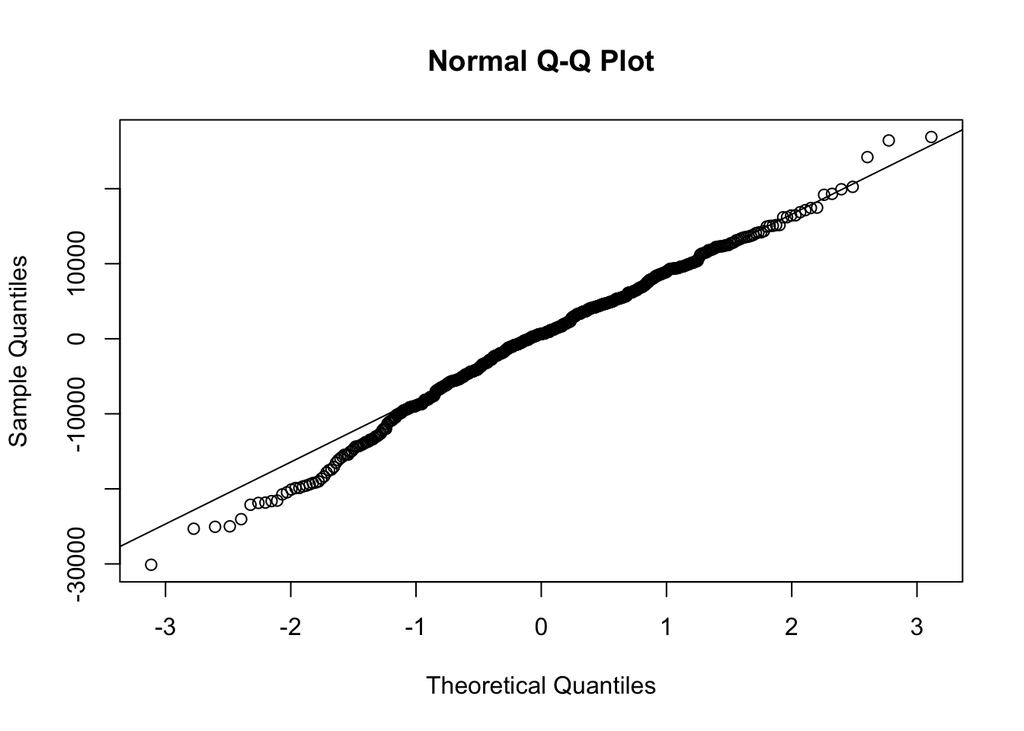

The qqnorm plot shows that the majority of the data falls on the “qqnormal” line which indicates that the residuals are normally distributed. The normality condition is therefore satisfied.

**Constant variance**:

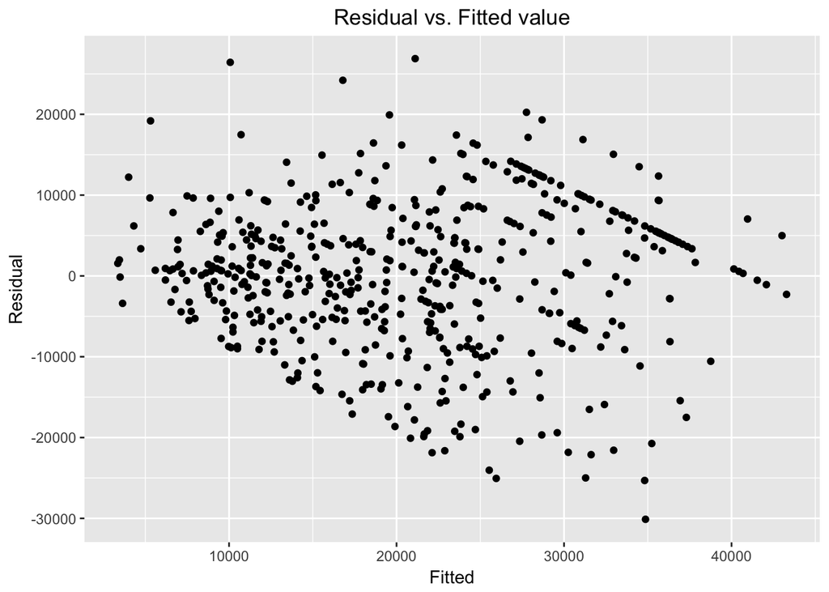

[output not shown]

The graph of residuals against the fitted values displays the seeming existence of a trend. However, this may be due to the fact that the calculations of the salary involved using the mean for the salary interval. Otherwise, it can be concluded that there is some sort of relationship that is yet to be observed that is being captured by the error term.

It may also be that the model is not of the correct form (i.e. polynomial form) due to the fact that some important predictors may have been missed from excluding limiting explanatory variable to those specifically interested in.

Although constance variance is not satisfied, performing a logarithmic transformation does not rectify this condition (the adjusted $R^2$ becomes 0.2879).

## 4.5 Pairwise t-tests

$H_o$: The mean of salary for one group is same as another group in a variable.

$H_a$: The mean of salary for one group is not the same as another group in a variable.

```
##
##  Pairwise comparisons using t tests with pooled SD
##
## data:  facQlfs$Salary and facQlfs$Education
##
##                  Degree  Higher Education A Level GCSE A*-C Other
## Higher Education 0.0026  -                -       -         -
## A Level          1.2e-07 1.0000           -       -         -
## GCSE A*-C        5.8e-11 0.9639           1.0000  -         -
## Other            2.6e-08 0.5435           0.9252  1.0000    -
## No               2.6e-06 0.6690           0.9639  1.0000    1.0000
##
## P value adjustment method: holm
```

```
##
##  Pairwise comparisons using t tests with pooled SD
##
## data:  facQlfs$Salary and facQlfs$Sex
##
##        Male
## Female <2e-16
##
## P value adjustment method: holm
```

```
##
##  Pairwise comparisons using t tests with pooled SD
##
## data:  facQlfs$Salary and facQlfs$Industry
##
##                                 Distribution, hotels, restaurants
## Banking, Finance                1.9e-10
## Public admin, education, health 0.0006
## Other                           5.4e-15
##                                 Banking, Finance
## Banking, Finance                -
## Public admin, education, health 8.2e-05
## Other                           0.6680
##                                 Public admin, education, health
## Banking, Finance                -
## Public admin, education, health -
## Other                           9.9e-08
##
## P value adjustment method: holm
```

```
##
##  Pairwise comparisons using t tests with pooled SD
##
## data:  facQlfs$Salary and facQlfs$NumEmployee
##
##           Under 50 Under 500
## Under 500 0.023    -
## Over 500  2.2e-10  1.2e-05
##
## P value adjustment method: holm
```

```
##
##  Pairwise comparisons using t tests with pooled SD
##
## data:  facQlfs$Salary and facQlfs$Occupation
##
##                                    Managers, Directors, Senior Officials
## Professional                       1.00000
## Associate Professional, Technical  0.12280
## Administrative, Secretarial        2.2e-09
## Skilled Trades                     0.00097
## Caring, Leisure, Other Service     < 2e-16
## Sales, Customer Service            < 2e-16
## Process, Plant, Machine Operatives 8.6e-06
## Elementary                         < 2e-16
##                                    Professional
## Professional                       -
## Associate Professional, Technical  0.37886
## Administrative, Secretarial        1.8e-09
## Skilled Trades                     0.00395
## Caring, Leisure, Other Service     < 2e-16
## Sales, Customer Service            < 2e-16
## Process, Plant, Machine Operatives 2.9e-05
## Elementary                         < 2e-16
##                                    Associate Professional, Technical
## Professional                       -
## Associate Professional, Technical  -
## Administrative, Secretarial        0.00043
## Skilled Trades                     0.52338
## Caring, Leisure, Other Service     3.5e-10
## Sales, Customer Service            1.1e-10
## Process, Plant, Machine Operatives 0.02619
## Elementary                         1.5e-11
##                                    Administrative, Secretarial
## Professional                       -
## Associate Professional, Technical  -
## Administrative, Secretarial        -
## Skilled Trades                     0.27701
## Caring, Leisure, Other Service     0.20136
## Sales, Customer Service            0.05004
## Process, Plant, Machine Operatives 1.00000
```

[output cut: 24 more lines]

```
## Caring, Leisure, Other Service     -
## Sales, Customer Service            -
## Process, Plant, Machine Operatives 0.08056
## Elementary                         1.00000
##                                    Process, Plant, Machine Operatives
## Professional                       -
## Associate Professional, Technical  -
## Administrative, Secretarial        -
## Skilled Trades                     -
## Caring, Leisure, Other Service     -
## Sales, Customer Service            -
## Process, Plant, Machine Operatives -
## Elementary                         0.03473
##
## P value adjustment method: holm
```

Notice that the pairwise t-test compares every category of a variable and checks whether there is a significant mean difference between them. However, the limitation is the assumption that the data set follows a normal distribution. The data set is, however, not normally distributed considering majority of the variables are categorical in nature.

**NumEmployee**: There is significant evidence to prove that there are different means of salary for NumEmployee between each category on average.

**Sex**: There is significant difference between the two genders. This could indicate the existence of gender discrimination. Considering the 1.07 ratio of female to male observations, the discrimination cannot be regarded as merely a sampling error.

**Industry**: There is significant evidence to prove that the mean is different between each category within the Industry variable except for the “Banking & Finance” and “Other” groups.

# 5. Discussion and Conclusion

The aim of this project is to develop a regression model predicting a person’s salary. The data set about the labour workforce of the United Kingdom provided by the UK Office for National Statistics initially included 739 variables and 88,528 observations. Guided by the literature, a subset of 11 variables of interest were selected: age, sex, occupation, industry, education, number of employees, religion, marital status, ethnicity and region of workplace. Regarding these identified variables, the data set was explored descriptively and statistical tests such as the Student’s t-test and Chi-square test were performed to investigate the significance and influence of the different variables leading to interesting results.

A counterintuitive finding revealed that ethnicity is not significant and can be excluded from the regression model. However, when considering the limited numbers of observations of ethnicities other than “white”, the results are less surprising (White: 486, Asian: 21, Black: 15 , Other: 21).

The bivariate data exploration of the variables education and occupation, education and industry led to the conclusion that both tuples of variables are not independent and must be included in a subsequent linear regression model.

Overall, the findings led to a reduced set of variables which only include age, sex, occupation, industry, education and number of employees serving as independent variables for the development of a linear regression model predicting salary.

Generally, the model can be used to answer questions regarding monetary securities (such as loans, credit card debt repayment). Moreover, customised offers and advertisements can be sent to clients and customers driving a company’s business success. Given a non-discriminating and exaggerated circumstances, a customer with a very low salary would for instance receive advertisements or discount coupons for purchasing toothpaste whilst a customer with a high salary would receive an invitation to try out a new sports car model. In both situations, there is a form of mutualism in play in terms of both the customer’s satisfaction and the business’s return.

After exploring the selected data set descriptively and building a linear regression model predicting the salary of people of different sex, age, educational qualifications and industries, the subsequent action is to test the accuracy of the developed predictive model. Thus, testing the model on more data sets is required. This would serve as a reference in validating the performance analysis of the model.

The applicability of the conceived model on other countries with similar socio-economical structures can then be tested. An interesting study would therefore be to determine whether the developed model predicts the salary for citizens of those countries with sufficient accuracy. If this is satisfied, other european countries could potentially apply the model. Furthermore, based on the findings, an adapted and more specific questionnaire could minimise the need to exclude observations. Undoubtedly, one should not restrict this to the extent where it is biased. The removal of this limitation could result in a potential improvement of the accuracy of the predictive model.

# 6. Project Github Repository

[Link for Project Github Repository](https://github.com/wygdd/MSF_Project)

# 7. References

Blinder, S. A. (1973) ‘Wage Discrimination: Reduced Form and Structural Estimates’, The Journal of Human Resources, 8(4), pp. 436-455. [Accessed 11 October 2017] Available at: http://www.jstor.org/stable/pdf/144855.pdf?refreqid=excelsior%3Aaabd22fcb1bb4b577ca37a51c72dea58

Bovill, D. (2015) ‘Annual Survey of Hours and Earnings: 2015 Provisional Results’ [Accessed 12 October 2017] Available at: https://www.ons.gov.uk/employmentandlabourmarket/peopleinwork/earningsandworkinghours/bulletins/annualsurveyofhoursandearnings/2015provisionalresults

Brynin, M and Güveli, A. (2012) ‘Understanding the ethnic pay gap in Britain’, Work, employment and society, 26(4), pp. 574-587. [Accessed 10 October 2017] Available at: http://journals.sagepub.com/doi/pdf/10.1177/0950017012445095

European Union (2014) ‘Tackling the gender pay gap in the European Union’, pp. 15. [Accessed 10 October 2017] Available at: http://ec.europa.eu/justice/gender-equality/files/gender_pay_gap/140319_gpg_en.pdf

Gerhard, U., Schwarzer, A. and Slupik, V. (eds) (1988) ‘Auf Kosten der Frauen. Frauenrechte im Sozialstaat’, Weinheim/Basel: Beltz Verlag.

Kickbusch, I. and Riedmüller, B. (eds) (1984) ‘Die armen Frauen. Frauen und Sozialpolitik’, Frankfurt/Main: Suhrkamp.

Mattila, A. and Choi, C. (2013) ‘An Analysis of Consumers’ Reactions to Travel Websites’ Discrimination by Computer Platform’ Cornell Hospitality Quarterly, 55(2), 210-215 Journals.sagepub.com. [Accessed 13 Oct. 2017]. Available at: http://journals.sagepub.com/doi/pdf/10.1177/1938965513509879

Office for National Statistics Social Survey Division, Northern Ireland Statistics and Research Agency. Central Survey Unit (ONS) (2017), ‘Quarterly Labour Force Survey, January - March, 2017’, UK Data Service. [Accessed 27 September 2017] Available at: http://doi.org/10.5255/UKDA-SN-8195-1

United Nations (2017). *‘United Nations Sustainable Development: Gender equality and women’s empowerment.’* [Accessed 11 October 2017] Available at: http://www.un.org/sustainabledevelopment/gender-equality/